# Larsson2019

Wancen Mu, Hirak Sarkar, Avi Srivastava, Kwangbom Choi, Rob Patro, Michael I. Love

Feb 1, 2021

Abstract

Airpart identifies sets of genes displaying differential cell-type-specific allelic imbalance across cell types or states, utilizing single-cell allelic counts. It makes use of a generalized fused lasso with binomial observations of allelic counts to partition cell types by their allelic imbalance. Alternatively, a nonparametric method for partitioning cell types is offered. The package includes a number of visualizations and quality control functions for examining single cell allelic imbalance datasets.

# Load data

First, we load the preprocessed [Larsson 2019](https://www.nature.com/articles/s41586-018-0836-1) data. It includes one allelic counts(`c57`) and the other allelic counts(`cast`) which was derived after removing some low quality cells indicated in the paper. `celltype` is a character vector of all cell types.

```r
suppressPackageStartupMessages(library(SingleCellExperiment))
load("../data/larsson.rda")
cell_meta_unique <- c("mESC","G1","S","G2M")
order_of_development <- order(match(celltype$x,cell_meta_unique))
assay.list<-list(a1=c57[,order_of_development],a2=cast[,order_of_development])
coldata<-data.frame(x=factor(celltype$x[order_of_development],levels=cell_meta_unique))
sce<-SingleCellExperiment(assays=assay.list, colData=coldata)
```

# Create Ratio matrix

Here we add the pseudo count for gene clustering and visualization.

```r
sce <- preprocess(sce)
```

Take a look at highest expressed genes

```r
counts(sce)[order(rowSums(counts(sce)),decreasing = T)[1:10],sample(dim(sce)[2],5)]
```

```
##        SS3_mESC_p1_F4_S30 SS3_MAF_leo180223_p4_S115 SS3_mESC_p1_H3_S24
## Malat1                286                       299                142
## Acta2                   0                       212                  0
## Sparc                  18                       147                 25
## Lgals1                  0                       223                  0
## Rps3                  223                        72                 89
## Col1a1                  2                       124                  0
## Thbs1                   0                       142                  0
## Rpl13a                189                        64                 72
## Rps11                 175                        94                 75
## S100a6                  0                       125                  0
##        SS3_mESC_p2_H9_S72 SS3_MAF_Leo171129_p2_S42
## Malat1                549                      949
## Acta2                   0                      618
## Sparc                  30                      281
## Lgals1                  0                      313
## Rps3                  184                      207
## Col1a1                  0                      360
## Thbs1                   0                      403
## Rpl13a                164                      148
## Rps11                 151                      132
## S100a6                  0                      228
```

# Quality control step

### QC on cells

```r
cellQCmetrics<-cellQC(sce,mad_detected=3,mad_spikegenes = 4,spike = "Ercc")
cellQCmetrics
```

```
## DataFrame with 412 rows and 7 columns
##                                  x       sum  detected spikePercent filter_sum
##                           <factor> <numeric> <numeric>    <numeric>  <logical>
## SS3_mESC_p1_A1_S1             mESC   4.31542      4186    0.0532353       TRUE
## SS3_mESC_p1_E1_S5             mESC   4.40846      4668    0.0977020       TRUE
## SS3_mESC_p1_C3_S19            mESC   4.44761      4796    0.0321199       TRUE
## SS3_mESC_p1_F2_S14            mESC   4.37374      4717    0.0507765       TRUE
## SS3_mESC_p1_A3_S17            mESC   4.08785      3356    0.0572129       TRUE
## ...                            ...       ...       ...          ...        ...
## SS3_MAF_leo180223_p4_S150      G2M   4.02206      2981    0.0760963       TRUE
## SS3_MAF_leo180223_p4_S151      G2M   4.56083      5521    0.0605144       TRUE
## SS3_MAF_leo180223_p4_S158      G2M   4.67636      6343    0.0632471       TRUE
## SS3_MAF_leo180223_p4_S187      G2M   4.16029      3756    0.0830335       TRUE
## SS3_MAF_leo180223_p4_S191      G2M   4.01812      2486    0.0479800       TRUE
##                           filter_detected filter_spike
##                                 <logical>    <logical>
## SS3_mESC_p1_A1_S1                    TRUE         TRUE
## SS3_mESC_p1_E1_S5                    TRUE         TRUE
## SS3_mESC_p1_C3_S19                   TRUE         TRUE
## SS3_mESC_p1_F2_S14                   TRUE         TRUE
## SS3_mESC_p1_A3_S17                   TRUE         TRUE
## ...                                   ...          ...
## SS3_MAF_leo180223_p4_S150            TRUE         TRUE
## SS3_MAF_leo180223_p4_S151            TRUE         TRUE
## SS3_MAF_leo180223_p4_S158            TRUE         TRUE
## SS3_MAF_leo180223_p4_S187            TRUE         TRUE
## SS3_MAF_leo180223_p4_S191           FALSE         TRUE
```

Now define cell filtering automatically or users can manually filter out based on `sum`,`detected` and `spikePercent`.

```r
keep_cell <- (
  cellQCmetrics$filter_sum & # sufficient features (genes)
  cellQCmetrics$filter_detected & # sufficient molecules counted
  cellQCmetrics$filter_spike  # sufficient features expressed compared to spike genes, high quality cells
)
table(keep_cell)
```

```
## keep_cell
## FALSE  TRUE
##    16   396
```

```r
sce<-sce[,keep_cell]
```

### QC on genes

Note that we require genes expressed in at least **25%** cells within each cell types.

```r
featureQCmetric<-featureQC(sce,spike = "Ercc",sd = 0.025)
keep_feature<-(featureQCmetric$filter_celltype &
                 featureQCmetric$filter_sd &
                 featureQCmetric$filter_spike)
table(keep_feature)
```

```
## keep_feature
## FALSE  TRUE
##  7441  2580
```

```r
sce<-sce[keep_feature,]
```

# Gene clustering

We provide two methods for gene clustering. Gaussian mixture modeling was used in this case and we set a relatively small number of cluster so that a larger gene set may more meaningful in GO term analysis. Hierarchical clustering is an alternative way for clustering.

### Gaussian Mixture modeling

Gaussian mixture modeling is the default method for gene clustering. The scatter plot is shown based on top 2 PCs of the smoothed allelic ratio data. The argument `plot=FALSE` can be used to avoid showing the plot. We have found gene clusters more spread out, more extreme allelic imbalance they have.

```r
sce<-geneCluster(sce, G=c(20,24,28))
```

```
## model-based optimal number of clusters: 28
```

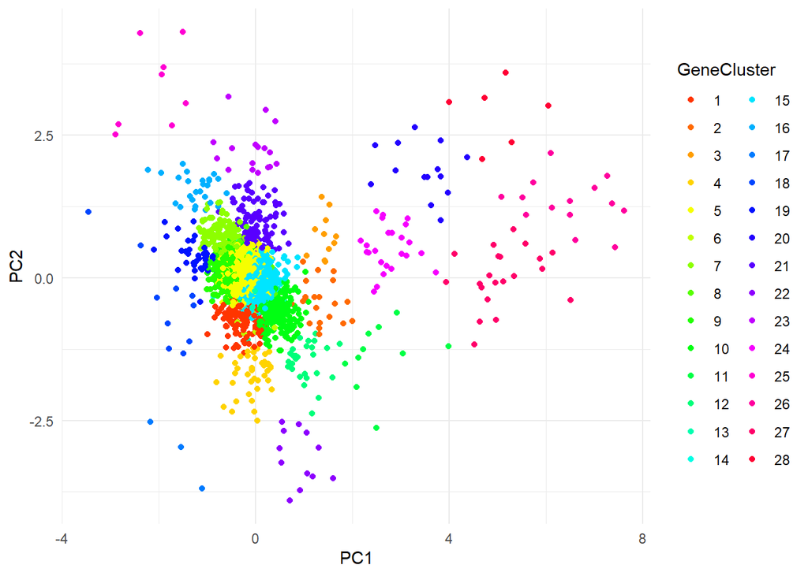

```r
metadata(sce)$geneCluster
```

```
##  [1] 130  21  11  40 878   7 123   7 270 207  10  27  13   9 527  27   3  10  39
## [20]  14 105  12  17  24   8  14  21   6
```

#### Exclude chromosome X genes

Sex typeing allelic imbalance are excluded because we want to focus on genetically-driven AI. And `GMM` can actually successfully detected chr x and some imprinted genes in one gene cluster as below figure shows there are monoallelic pattern among fibroblast cells but in a coordinate way. So after removing all the genes on chromosome X, we redo the gene cluster step.

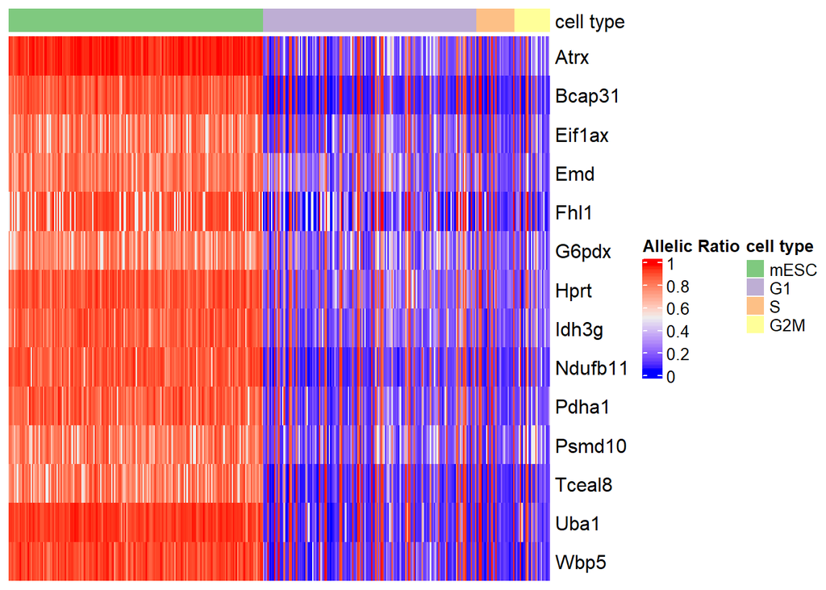

```r
makeHeatmap(sce,genecluster=26, show_row_names = TRUE)
```

```r
suppressMessages(suppressWarnings(library(GenomicFeatures)))
suppressMessages(suppressWarnings(library("org.Mm.eg.db")))
txdb <- makeTxDbFromGFF("ftp://ftp.ebi.ac.uk/pub/databases/gencode/Gencode_mouse/release_M1/gencode.vM1.annotation.gtf.gz")
g <- genes(txdb)
g$sym <- mapIds(org.Mm.eg.db, sub("\\..*","",names(g)), "SYMBOL", "ENSEMBL")
g <- g[!is.na(g$sym)]
```

```r
load("../data/mm9_genome.rda")
gene_chrx<- unname(g$sym[which(seqnames(g)=="chrX")])
sce <- sce[-which(rownames(sce)%in%gene_chrx),]
```

```r
sce<-geneCluster(sce, G=5)
```

```
## model-based optimal number of clusters: 5
```

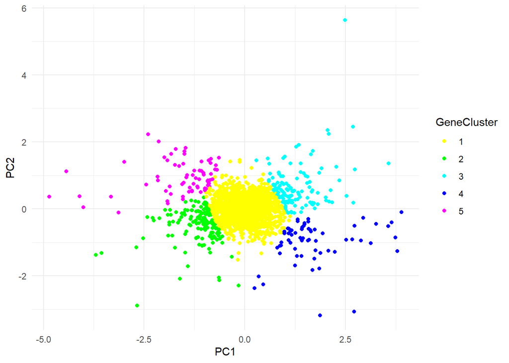

```r
metadata(sce)$geneCluster
```

```
## [1] 2069  149  128   66   69
```

#### Generating null data and shows number of gene cluster is 1

To show that above gene clusters are not false positive, we simulated null allelic ratio 0.5 to all genes and it turns out only has one gene cluster.

```
## model-based optimal number of clusters: 1
```

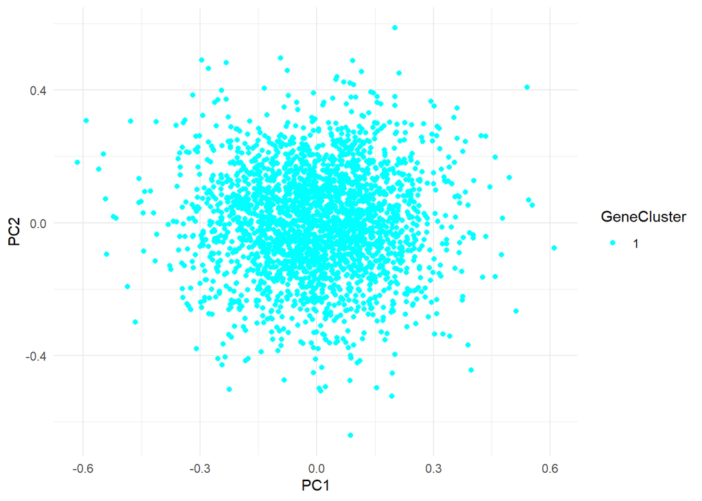

```r
cts <- counts(sce)
a1 <- matrix(emdbook::rbetabinom(dim(cts)[1]*dim(cts)[2],
                             prob = 0.5,
                             size = cts,
                             theta = 20), ncol = dim(cts)[2])
a2 <- cts - a1
assay.list<-list(a1=a1,a2=a2)
sce.null<-SingleCellExperiment(assays=assay.list, colData=colData(sce))
sce.null <- preprocess(sce.null)
# jpeg(file="C:/Users/UNC Support/OneDrive - University of North Carolina at Chapel Hill/Lab/GRA/plot/cluster_null.jpeg",width = 8, height = 7,units = "in",res=450)
sce.null<-geneCluster(sce.null, G=c(1:4))
```

```r
# dev.off()
metadata(sce.null)$geneCluster
```

```
## [1] 2481
```

# Running airpart

### Simple summary table of alleic ratio

Quickly look at the weighted mean of allelic ratio for each gene cluster. Identify the interested gene cluster. The following step is a complement of the QC on genes step. We recommend users only run *airpart* when the largest ordered allelic ratio difference > 0.05 for speed concerns. We find that the allelic ratio of most of the gene clusters in such cases (small absolute allelic ratio differences) won’t provide enough evidence to detect differential allelic imbalance.

```r
summary<-summaryAllelicRatio(sce)
sapply(1:length(summary), function(i) {
  inst <- summary[[i]]
  inst_order <- inst[order(inst$weighted.mean), ]
  max(diff(inst_order$weighted.mean)) > 0.05
})
```

```
## [1] FALSE  TRUE  TRUE  TRUE  TRUE
```

Here we use gene cluster 3 as an example.

### Experiment-wide beta-binomial over-dispersion

We recommend examining the experiment-wide beta-binomial over-dispersion, which helps to inform whether to use a binomial likelihood or a nonparametric approach to partitioning the cell types by allelic imbalance.

For gene cluster 3, we use fussed lasso method to infer partition.

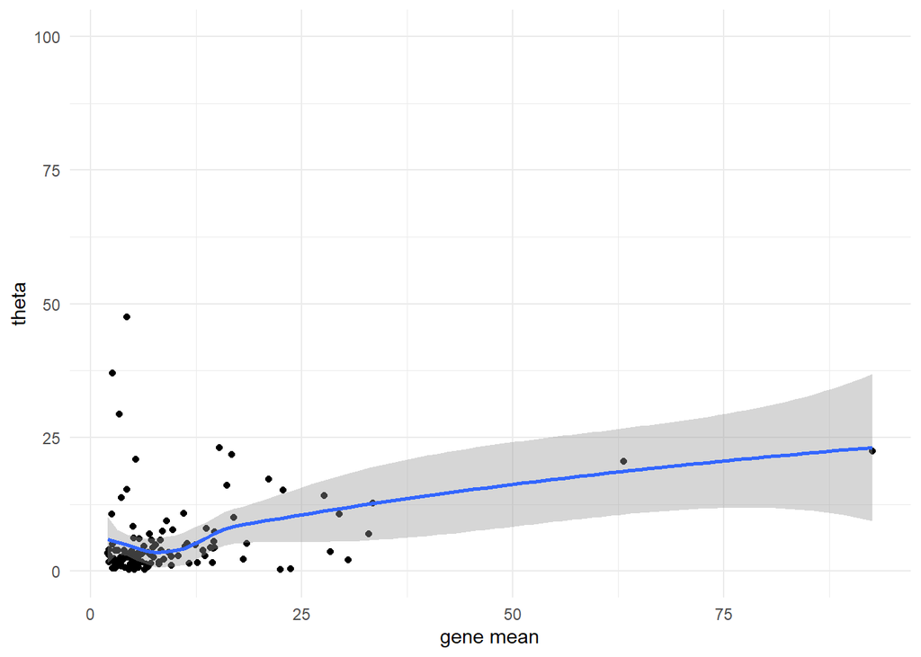

```r
estDisp(sce,genecluster = 3)
```

### Modeling using fused lasso with binomial likelihood

*airpart* offers a method for partitioning cell types using the generalized fused lasso with binomial likelihood, as implemented in the *smurf* package. Cell types are merged based on their similarity of allelic ratios, accounting for excess variability on the ratio from low counts. The penalization is determined using deviance on held-out data, with a 1 SE cross-validation rule for favoring smaller models (more fused cell types).

```r
sce_sub <- fusedLasso(sce,
  model = "binomial",
  genecluster = 3, ncores = 4
)
```

Use table and heatmap to visualize the result.

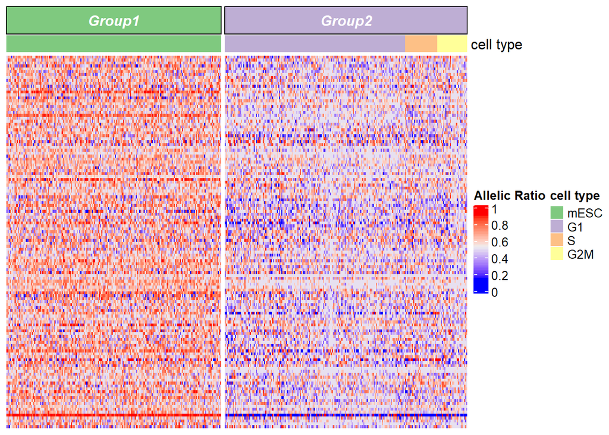

```r
# knitr::kable(metadata(sce_sub)$partition, row.names = FALSE)
# jpeg(file="C:/Users/wancen/OneDrive - University of North Carolina at Chapel Hill/Lab/GRA/plot/heatmap_larsson.jpeg",width = 8, height = 6,units = "in",res=450)
makeHeatmap(sce_sub, order_by_group = FALSE,show_row_names = F)
```

```r
# dev.off()
```

Here `ncores` is the number of CPU used for parallelization. Note, the computation time increases approximate linearly as number of genes increases. If you run `niter>1`, please use a `consensusPart` to derive the final partition.

### Calculating allelic ratio estimate via hierarchical Bayesian modeling

After *airpart* determines a partition of cell types either by the fused lasso with binomial likelihood or the nonparametric approach described above, it give fused lasso estimate or weighted mean as prior Cauchy mean to estimate the allelic ratio per gene and per cell type (and credible intervals) via beta-binomial loglikelihood, using functionality from the *apeglm* package.

Note that the estimates and credible intervals are not equal for genes, because in this step we re-estimate the conditional cell type means per partition group and accounting for each gene overdispersion. The dispersion parameter is using Efron-like formula shrinkage.

```r
sce_sub <- allelicRatio(sce_sub)
svalue <- extractResult(sce_sub,estimates = "svalue")
fsr <- extractResult(sce_sub,estimates = "fsr")
lower <- extractResult(sce_sub,"lower")
upper <- extractResult(sce_sub,"upper")
## number of genes are allelic imbalance in stem cell
indexci<- which(svalue[,1]<0.005)
length(indexci)
```

```
## [1] 128
```

```r
## number of genes are allelic imbalance in fibroblast
indexci<- which(svalue[,2]<0.005)
length(indexci)
```

```
## [1] 85
```

```r
jpeg(file="C:/Users/wancen/OneDrive - University of North Carolina at Chapel Hill/Lab/GRA/plot/larssonviolin2.jpeg",width = 4.5, height = 2.5,units = "in",res=450)
makeViolin(sce_sub)
dev.off()
```

```
## svalue shown in columns per cell type
```

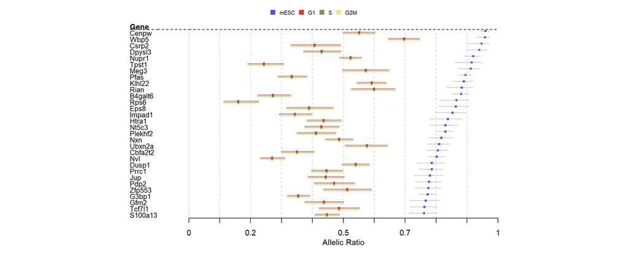

```r
# jpeg(file="C:/Users/wancen/OneDrive - University of North Carolina at Chapel Hill/Lab/GRA/plot/forest.jpeg",width = 10, height = 6,units = "in",res=450)
makeForest(sce_sub,showtext = FALSE)
```

```r
# dev.off()
```

# GO term analysis

Through GO term evaluation, we can find indeed `response to leukemia inhibitory factor` GO terms(GO:1990823) has the most significant adjust p value = 0.136.

```r
suppressMessages(suppressWarnings(library(goseq)))
suppressMessages(suppressWarnings(library(kableExtra)))
i=3
feat<-which(rowData(sce)$cluster==i)
genes <- rep(0,nrow(sce))
names(genes) <- rownames(sce)
genes[feat] <- 1
table(genes)
```

genes 0 1 2353 128

```r
suppressMessages(pwf <- nullp(genes, "mm9", "geneSymbol"))
```

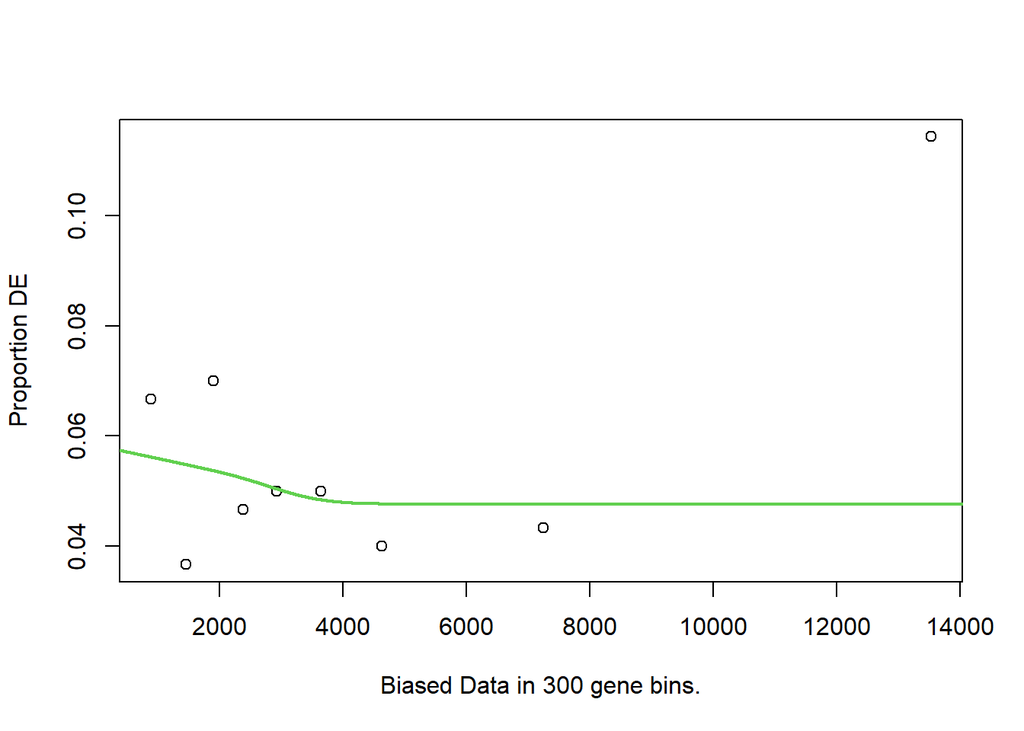

```r
suppressMessages(gores <- goseq(pwf, "mm9", "geneSymbol"))
p_adjust <- p.adjust(gores$over_represented_pvalue,method = "fdr")
gores$`p.adjust`<-p_adjust
head(gores[gores$ontology=="BP" & gores$numInCat>15,], 15) %>%
  kbl() %>%
  kable_paper("hover", full_width = F)
```

|  | category | over_represented_pvalue | under_represented_pvalue | numDEInCat | numInCat | term | ontology | p.adjust |
| --- | --- | --- | --- | --- | --- | --- | --- | --- |
| 12715 | GO:1990823 | 0.0000208 | 0.9999972 | 10 | 40 | response to leukemia inhibitory factor | BP | 0.1360012 |
| 12719 | GO:1990830 | 0.0000208 | 0.9999972 | 10 | 40 | cellular response to leukemia inhibitory factor | BP | 0.1360012 |
| 9927 | GO:0071345 | 0.0014724 | 0.9995099 | 15 | 125 | cellular response to cytokine stimulus | BP | 1.0000000 |
| 3102 | GO:0010817 | 0.0034406 | 0.9991982 | 8 | 50 | regulation of hormone levels | BP | 1.0000000 |
| 7820 | GO:0046879 | 0.0035772 | 0.9993795 | 6 | 30 | hormone secretion | BP | 1.0000000 |
| 2858 | GO:0009914 | 0.0042268 | 0.9992378 | 6 | 31 | hormone transport | BP | 1.0000000 |
| 5659 | GO:0034097 | 0.0045641 | 0.9982729 | 15 | 140 | response to cytokine | BP | 1.0000000 |
| 8048 | GO:0048523 | 0.0068744 | 0.9960549 | 49 | 697 | negative regulation of cellular process | BP | 1.0000000 |
| 4538 | GO:0030336 | 0.0073236 | 0.9984966 | 6 | 35 | negative regulation of cell migration | BP | 1.0000000 |
| 2455 | GO:0008283 | 0.0080852 | 0.9960378 | 24 | 282 | cell population proliferation | BP | 1.0000000 |
| 4835 | GO:0031324 | 0.0096354 | 0.9948750 | 30 | 383 | negative regulation of cellular metabolic process | BP | 1.0000000 |
| 6471 | GO:0042127 | 0.0098683 | 0.9952934 | 21 | 240 | regulation of cell population proliferation | BP | 1.0000000 |
| 1734 | GO:0006259 | 0.0098824 | 0.9958988 | 15 | 151 | DNA metabolic process | BP | 1.0000000 |
| 4585 | GO:0030534 | 0.0101482 | 0.9986252 | 4 | 17 | adult behavior | BP | 1.0000000 |
| 2332 | GO:0007610 | 0.0103787 | 0.9967666 | 9 | 72 | behavior | BP | 1.0000000 |

# Enrichment analysis

To access whether this gene cluster has significant differential allelic imbalance pattern other than null cluster and is correlated with enhancer activity, enrichment analysis was performed between C57 allele h3k27ac peaks and the DAI gene cluster.

### load non-allelic chip-seq data

```r
mESC<-read_narrowpeaks("../data/mESC.narrowPeak",genome_info = "mm9")
colnames(mcols(mESC))<-c("name","score","fold_enrichment","-log(pvalue)","-log(FDR)/log(10)","summit")
mESC_filter<-mESC[which(mcols(mESC)$fold_enrichment>15)]

mef<-read_narrowpeaks("../data/mef.narrowPeak",genome_info = "mm9")
colnames(mcols(mef))<-c("name","score","fold_enrichment","-log(pvalue)","-log(FDR)/log(10)","summit")
mef_filter<-mef[which(mcols(mef)$fold_enrichment>15)]

## Map IDs
suppressMessages(suppressWarnings(library(GenomicFeatures)))
suppressMessages(suppressWarnings(library("org.Mm.eg.db")))
txdb <- makeTxDbFromGFF("ftp://ftp.ebi.ac.uk/pub/databases/gencode/Gencode_mouse/release_M1/gencode.vM1.annotation.gtf.gz")
```

```
## Import genomic features from the file as a GRanges object ... OK
## Prepare the 'metadata' data frame ... OK
## Make the TxDb object ...
```

```
## OK
```

```r
g <- genes(txdb)
g$sym <- mapIds(org.Mm.eg.db, sub("\\..*","",names(g)), "SYMBOL", "ENSEMBL")
g <- g[!is.na(g$sym)]

## Define gene promoters
prom <- promoters(g, upstream = 2000, downstream = 200)
```

### Define helper function

```r
## Get allelic imbalance genes
get_overlap<-function(prom,feat,mESC,mef){
  poi<-which(mcols(prom)$sym %in% feat)
  g2<-prom[poi]

  mESC_ov<-join_overlap_inner(g2, mESC)
  mef_ov<-join_overlap_inner(g2, mef)


  mESC_ov2 <- mESC_ov %>%
    group_by(sym) %>%
    summarize(
      fold_enrichment=max(fold_enrichment),
      peak_count=sum(!is.na(fold_enrichment)))

  mef_ov2 <- mef_ov %>%
    group_by(sym) %>%
    summarize(
      fold_enrichment=max(fold_enrichment),
      peak_count=sum(!is.na(fold_enrichment)))

  enrich<-merge(mESC_ov2,mef_ov2,by="sym",all=T)
  return(enrich)
}
```

### Define Gene set of interest and null sets

```r
i=3
feat<-rownames(sce)[which(rowData(sce)$cluster==i)]

## null set
j=1
feat_other<-rownames(sce)[which(rowData(sce)$cluster==j)]
```

Fisher-exact test and permutation test were both used to test the assumption that stem cell enrichment versus fibroblast enrichment is correlated with gene cluster.

### Fisher-exact test for countoverlap

```r
# Calculate overlap counts
overlaptxb_prom<-get_overlap(prom,feat,mESC_filter,mef_filter)
overlaptxb_prom_total<- c(sum(overlaptxb_prom$peak_count.x,na.rm = T),sum(overlaptxb_prom$peak_count.y,na.rm = T))
overlaptxb_other_prom<-get_overlap(prom,feat_other,mESC_filter,mef_filter)

overlaptxb_otherprom_total<- c(sum(overlaptxb_other_prom$peak_count.x,na.rm = T),sum(overlaptxb_other_prom$peak_count.y,na.rm = T))
```

```r
contagency_table<-matrix(c(overlaptxb_prom_total,overlaptxb_otherprom_total),ncol=2,byrow = T)
print(contagency_table)
```

```
##      [,1] [,2]
## [1,]   59   36
## [2,]  565  747
```

```r
## calculate pvalue
res<-fisher.test(contagency_table,alternative = "g")
res$p.value
```

```
## [1] 0.0002401894
```

### Permutation test

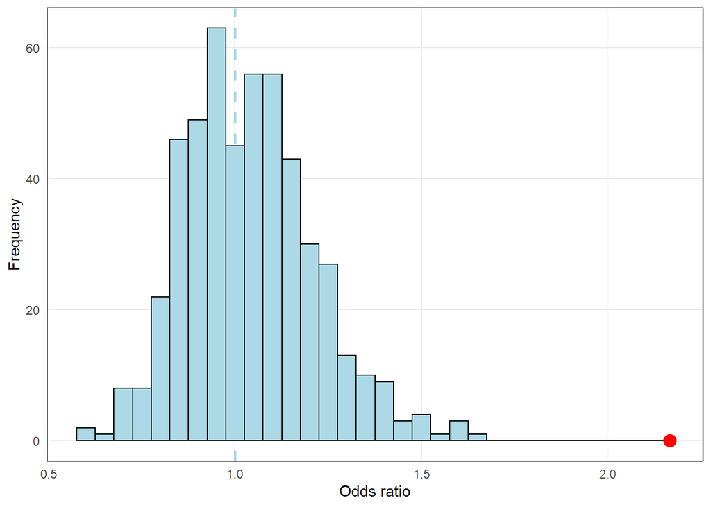

```r
library(pbapply)
or<-pbsapply(1:500,function(i){
  feat1 <- sample(c(feat,feat_other),length(feat))
  overlaptxb_prom<-get_overlap(prom,feat1,mESC_filter,mef_filter)
  overlaptxb_prom_total<- c(sum(overlaptxb_prom$peak_count.x,na.rm = T),sum(overlaptxb_prom$peak_count.y,na.rm = T))
  feat_other1 <- setdiff(c(feat,feat_other),feat1)
  overlaptxb_other_prom<-get_overlap(prom,feat_other1,mESC_filter,mef_filter)
  overlaptxb_otherprom_total<- c(sum(overlaptxb_other_prom$peak_count.x,na.rm = T),sum(overlaptxb_other_prom$peak_count.y,na.rm = T))
  res<-fisher.test(matrix(c(overlaptxb_prom_total,overlaptxb_otherprom_total),ncol=2,byrow =T),alternative = "g")
  return(res$estimate)
})
or <- data.frame(or = or)
p<-ggplot(or, aes(x=or)) +
  geom_histogram(color="black", fill="lightblue",binwidth=0.05) +
  # geom_density(alpha=.2, fill="#E69F00") +
  geom_vline(aes(xintercept=1),
            color="lightblue", linetype="dashed",size=1) +
  theme_minimal() +
  theme(panel.grid.minor = element_blank(),
        panel.border = element_rect(fill = 'transparent')) +
  labs(x = "Odds ratio",y="Frequency")+
  geom_point(
    data=data.frame(x=2.165635,y=0),
    aes(x,y),
    color="red",
    size=4)
# jpeg(file="C:/Users/wancen/OneDrive - University of North Carolina at Chapel Hill/Lab/GRA/plot/permutate.jpeg",width = 3, height = 2,units = "in",res=450)
p
```

```r
# dev.off()
```